# **Facteurs influençants la prise des transports en commun pour l’agglomération grenobloise**

RACHIDI Mustapha & SAUNIER Florent & SAADALLAH Malek

Janvier 2024

# Introduction

Ce projet se base sur des données récoltées par l’ENQUÊTE MÉNAGES DÉPLACEMENTS en 2010 dans la région Grenobloise. L’étude a pour but de déterminer les facteurs influençant la prise des transports en commun . Pour cela nous nous sommes pris comme limites : le réseau Mtag qui comprend les bus qualifiés de “ville” (Nous n’avons pas pris en compte les bus régionaux comme par exemple le bus Grenoble - Chamrousse) et le réseau du tramway dont les lignes depuis 2010 ont été augmentées.

# Etat de l’art

Notre recherche bibliographique a abouti à la sélection de ces facteurs supplémentaires :

| # | Authors | Year | Title | Source |
| --- | --- | --- | --- | --- |
| 1 | Paulley, N., Balcombe, R., Mackett, R., Titheridge, H., Preston, J., Wardman, M., … & White, P. | 2006 | The demand for public transport: The effects of fares, quality of service, income and car ownership. | Transport policy, 13(4), 295-306. |
| 2 | Redman, L., Friman, M., Gärling, T., & Hartig, T. | 2013 | Quality attributes of public transport that attract car users: A research review. | Transport policy, 25, 119-127. |
| 3 | Zhang, Wang, M., Dong, J., Lu, W., Liu, Y., Ni, A., & Yu, X. | 2022 | Factors and Mechanism Affecting the Attractiveness of Public Transport: Macroscopic and Microscopic Perspectives. | Journal of Advanced Transportation, 2022, 1–16. |
| 4 | Raşca, & Saeed, N. | 2022 | Exploring the factors influencing the use of public transport by commuters living in networks of small cities and towns. | Travel, Behaviour & Society, 28, 249–263. |
| 5 | Göransson, & Andersson, H. | 2023 | Factors that make public transport systems attractive: a review of travel preferences and travel mode choices. | European Transport Research Review, 15(1), 32–14. |

## State of the art

### Key factors from the literature

- *Socio-Economic Characteristics:* Factors like age, income, and individual’s financial situation.
- *Spatial Characteristics:* The percentage of origin and destination municipalities located in high-density areas.
- *General Mobility:* Access to a car and the frequency of using alternative modes of transport.
- *Alternative-Specific Variables:* Time, cost, comfort, and a combination of time and comfort.
- *Instrumental Motives:* Objective level of service variables like travel cost, travel time, and frequency of the transport service.

# Familiarisation avec la base de données

La base de données contient 30 702 lignes et 116 colonnes ce qui correspond à nos variables , on peut la qualifier de base de données “moyenne” mais qui saura nous occuper. Concernant le nombre de valeurs manquantes, toutes variables confondues nous avons 971 658 valeurs manquantes soit 27.3% de notre base de données. De plus, 0% des lignes ont toutes leurs valeurs et c’est 21% des colonnes qui n’ont pas de valeurs manquantes. Il peut être intéressant de voir où sont les valeurs manquantes. L’échantillon comporte 5189 personnes

En annexe, quelques graphiques permettant de visualiser quelles variables ont le plus de valeurs manquantes. Ces graphiques nous permettrons d’adopter un regard critique sur les variables que nous choisirons par la suite. Cependant, on peut établir quelques critères avec r : ration de valeurs manquantes dans la colonne.

Bon : r<=5% Moyen : 5%<r<=20% Mauvais 20%<r<=45% Très mauvais : r>45%

```
##
##  NON  OUI
##  866 3910
```

## Variables du projet

**Frecqtcu** : Variable d’intérêt (Y) catégorielle qui indique la fréquence d’utilisation des transports en communs chez une personne.Elle prend les valeurs :

1 : Utilisation des transports en commun tous les jours : Utilisation des transports en commun au moins deux fois par semaine : Utilisation des transports en commun au moins deux fois par mois : Utilisation des transports en commun très rare : Utilisation des transports en commun inexistante

Nous avons décidié de construire frecqtcu de manière à ce qu’elle prenne la valeur 0 ou 1

Pour toutes les personnes qui prennent les transports de manière : régulière/tous les jours , au moins deux fois par semaine et au moins deux fois par mois se sont vues attribuées la valeur 1 car le “au moins” présage une prise des transports en communs plus élevée.

**Tailmng** : Variable qui indique le nombre de personnes composant le ménage.

On change simplement le nom de la variable “NO_PERS” qui indique le nombre de personne dans le ménage **Permis** :Variable indiquant si la personne effectuant le trajet possède le permis ou pas.

**Car_ownership** : Variable indiquant si la personne effectuant le trajet possède une voiture pour ses déplacements

Cette variable dépent de trois variables qui sont VP_dispo qui doit être strictement supérieur à 0, puis GENRE (type de véhicule utilisé) , nous avons exclu les campings cars car notre sujet se prête au milieu urbain et de POSSE (Est ce que la voiture appartient à la personne).Nous nous sommes contentés de prendre exclusivement les véhicules possedés par la personne.

# Création de la nouvelle base de données

**Variables complémentaires** Grâce aux variables précédentes et aux articles que l’on a trouvé dans la littérature, nous allons construire notre base de données pour notre modèle. Nous exploiterons un ensemble de caractéristiques socio-économiques puis certaines variables liées au “confort” du trajet.

Cette base de données va regrouper toutes les variables nécessaires à notre étude puis on la redivisera encore par la suite pour notamment l’utilisation de cluster

**Restriction géographique** Définissons ce que l’on entend par “transports en communs”. Pour notre étude nous nous concentrons sur les transports en communs de la société MTag,c’est à dire les tram et bus du réseau. Notre délimitation géographique sera simplement les terminaux des différentes lignes de tram/bus confondues. Par la suite, quand on parlera de transports en communs, on se refère à la définition au dessus.

Toutes les zones répertoriées dans le vecteur “Vec_zone” ont au moins un arrêt du réseau Mtag.

**Restriction sur l’âge**

Il est nécessaire de préciser que les mineurs se déplacent majoritairement via les transports en communs car ils n’ont tout simplement pas le choix… Et aussi les étudiants car après plusieurs recherches, nous savons que les étudiants de l’étude utilisent majoritairement les transports en commun (plus de 80% d’entre eux), on détaillera cela un peu plus loin dans le rapport.

**Revue de la base de données** Il va falloir enlever les variables où il y a des valeurs manquantes

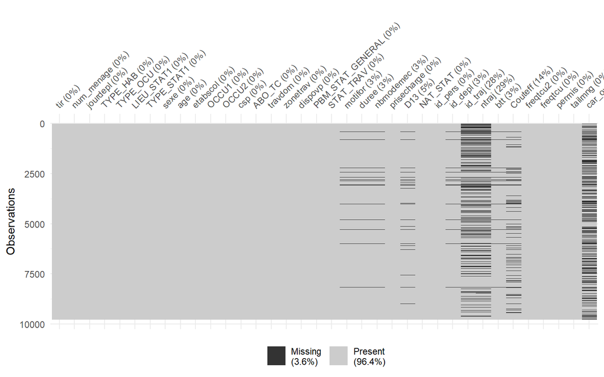

# Clustering

**Les étudiants**

**Test 0 Étudiants**

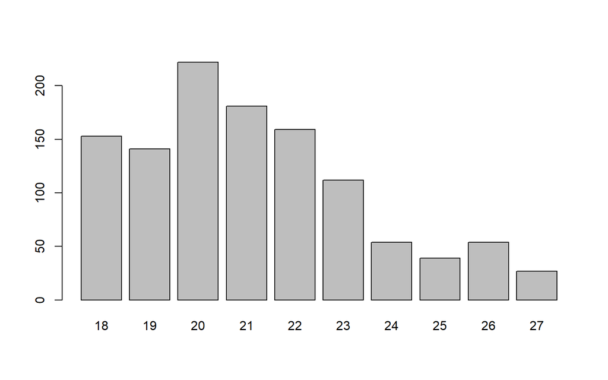

Les étudiants vont de 18 à 27 ans car au dessus on pouvait considérer certaines personnes comme des outliers , des personnes plus agés en reconversion certainement.

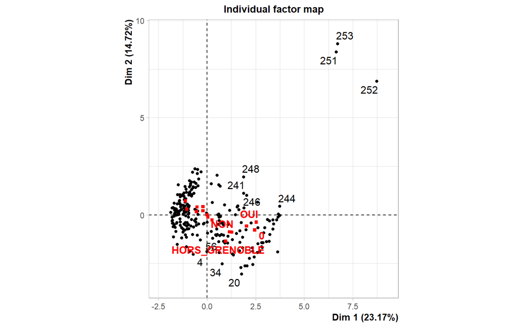

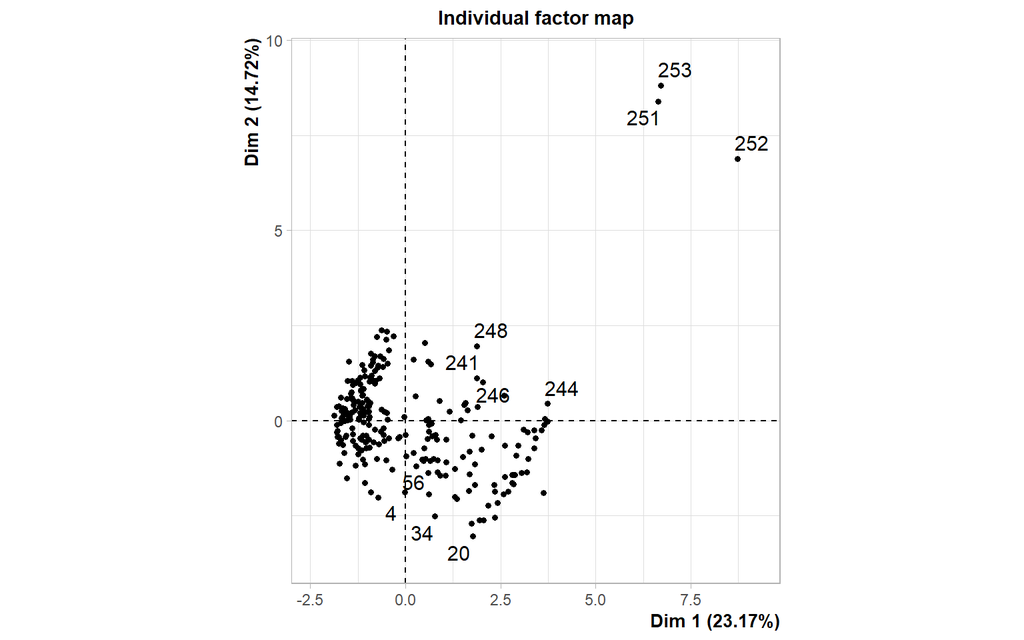

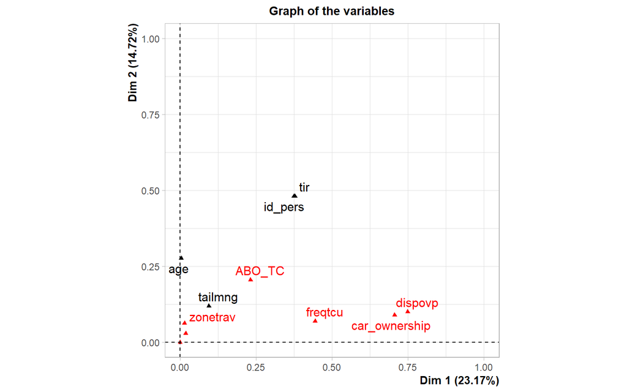

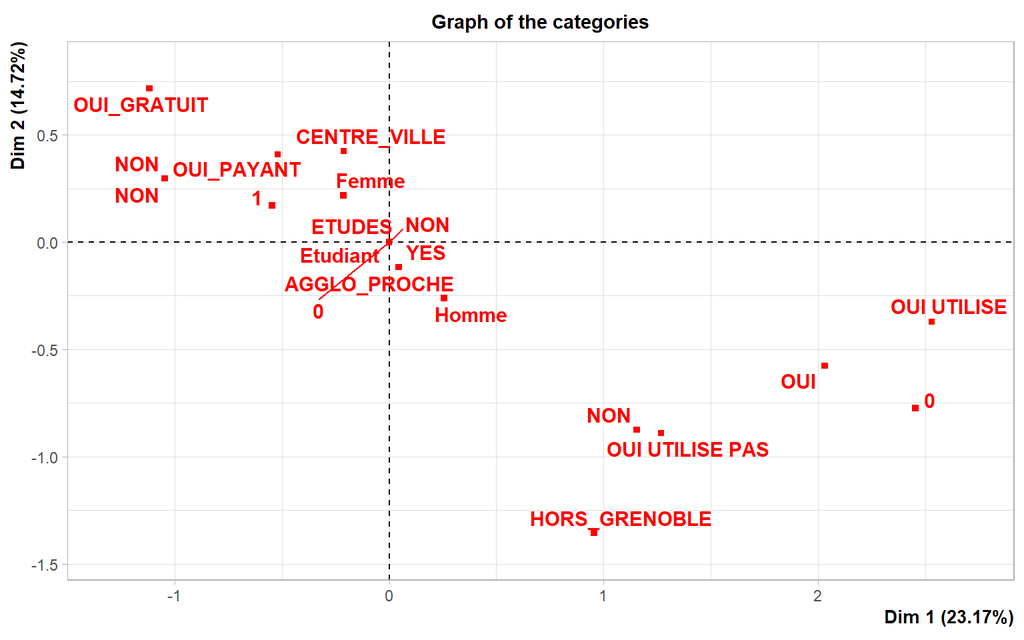

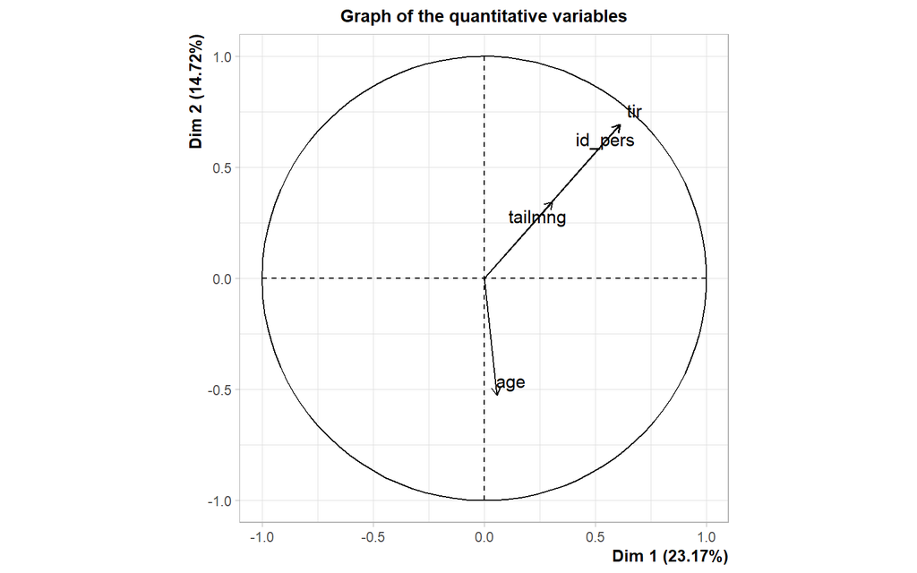

```
##
## Call:
## FAMD(base = DB_pers_socio_etu, ncp = 5)
##
##
## Eigenvalues
##                       Dim.1  Dim.2  Dim.3  Dim.4  Dim.5
## Variance              3.012  1.914  1.394  1.218  1.153
## % of var.            23.166 14.721 10.726  9.372  8.867
## Cumulative % of var. 23.166 37.887 48.613 57.985 66.852
##
## Individuals (the 10 first)
##                  Dist    Dim.1    ctr   cos2    Dim.2    ctr   cos2    Dim.3
## 1            |  2.820 | -1.593  0.333  0.319 |  0.320  0.021  0.013 |  0.387
## 2            |  2.742 | -1.708  0.383  0.388 | -0.060  0.001  0.000 |  0.088
## 3            |  2.642 | -1.521  0.303  0.331 |  0.205  0.009  0.006 | -0.365
## 4            |  6.228 | -0.717  0.067  0.013 | -2.023  0.845  0.106 | -0.239
## 5            |  3.077 | -1.740  0.397  0.320 | -1.123  0.260  0.133 | -0.192
## 6            |  2.270 | -1.812  0.431  0.637 | -0.295  0.018  0.017 | -0.353
## 7            |  4.445 | -1.878  0.463  0.179 |  0.142  0.004  0.001 | -0.500
## 8            |  2.376 | -1.762  0.408  0.550 | -0.596  0.073  0.063 | -0.279
## 9            |  2.452 | -1.607  0.339  0.429 | -0.846  0.148  0.119 |  0.263
## 10           |  2.126 | -1.603  0.337  0.569 |  0.000  0.000  0.000 | -0.796
##                 ctr   cos2
## 1             0.042  0.019 |
## 2             0.002  0.001 |
## 3             0.038  0.019 |
## 4             0.016  0.001 |
## 5             0.010  0.004 |
## 6             0.035  0.024 |
## 7             0.071  0.013 |
## 8             0.022  0.014 |
## 9             0.020  0.012 |
## 10            0.180  0.140 |
##
## Continuous variables
##                 Dim.1    ctr   cos2    Dim.2    ctr   cos2    Dim.3    ctr
## tir          |  0.614 12.538  0.378 |  0.693 25.118  0.481 |  0.195  2.719
## age          |  0.057  0.109  0.003 | -0.526 14.463  0.277 |  0.088  0.549
## id_pers      |  0.612 12.422  0.374 |  0.693 25.094  0.480 |  0.199  2.831
```

[output cut: 15 more lines]

```
## OUI_GRATUIT  | -1.119  0.982  0.088 -2.832 |  0.717  0.998  0.036  2.277 |
## OUI_PAYANT   | -0.520  1.766  0.295 -5.737 |  0.410  2.715  0.183  5.671 |
## NON          |  0.000  0.000  0.000  0.000 |  0.000  0.000  0.000  0.000 |
## AGGLO_PROCHE |  0.045  0.015  0.004  0.603 | -0.117  0.254  0.027 -1.956 |
##               Dim.3    ctr   cos2 v.test
## Femme        -0.344  3.311  0.132 -5.059 |
## Homme         0.412  3.973  0.132  5.059 |
## 0             0.000  0.000  0.000  0.000 |
## Etudiant      0.000  0.000  0.000  0.000 |
## ETUDES        0.000  0.000  0.000  0.000 |
## NON          -0.266  1.222  0.024 -2.543 |
## OUI_GRATUIT  -0.615  1.382  0.027 -2.287 |
## OUI_PAYANT    0.224  1.536  0.055  3.641 |
## NON           0.000  0.000  0.000  0.000 |
## AGGLO_PROCHE -0.325  3.690  0.208 -6.364 |
```

```
##         Dim.1        Dim.2       Dim.3        Dim.4      Dim.5
## 1  -1.5931764  0.319504403  0.38675300  1.275095273 -0.4578470
## 2  -1.7083374 -0.060172320  0.08776164 -0.006859689 -0.3691743
## 3  -1.5206611  0.204561937 -0.36520258  0.310298831 -0.1026692
## 4  -0.7169158 -2.022966707 -0.23905604  0.253017747  2.8279816
## 5  -1.7402926 -1.123014890 -0.19192426 -1.692926272  0.5651522
## 6  -1.8120502 -0.294949841 -0.35328506 -0.622893664  0.6849146
## 7  -1.8781387  0.141669676 -0.50029122  1.661758106 -2.2401906
## 8  -1.7622138 -0.596231271 -0.27883465 -1.064898214  0.6323107
## 9  -1.6065736 -0.845681656  0.26326464 -1.096852898 -0.4956236
## 10 -1.6032158 -0.000235632 -0.79633131 -0.319743388  0.9467153
```

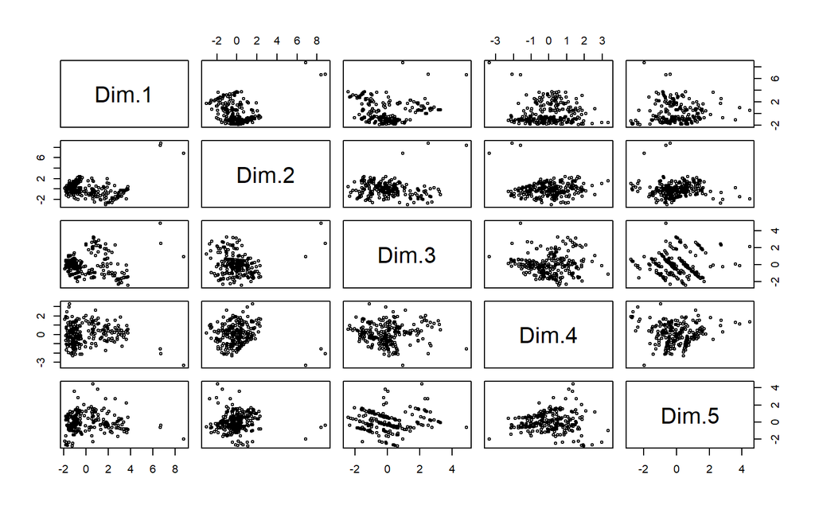

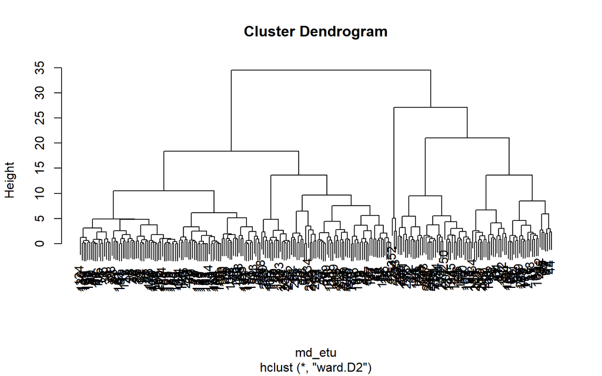

```
## groups_etu
##   1   2
## 167  86
```

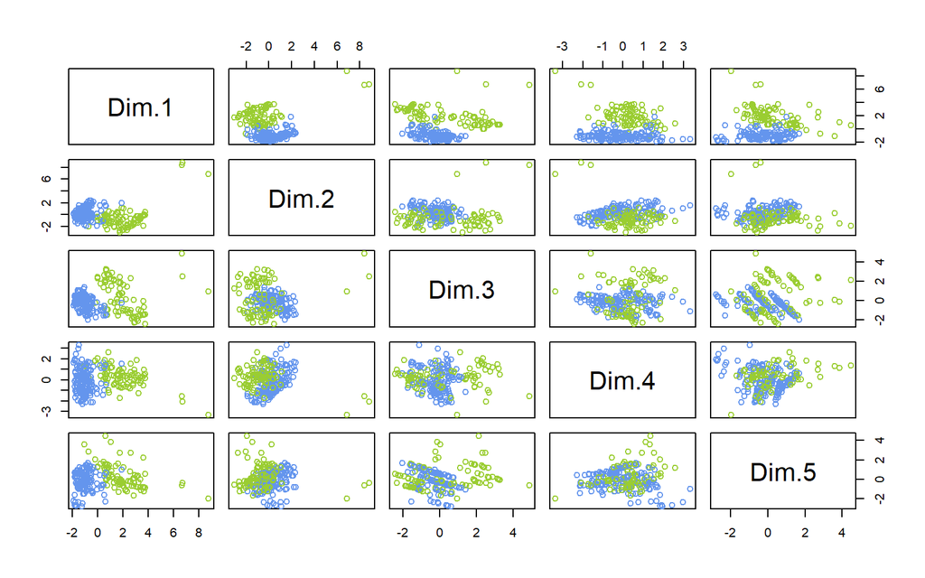

```
##          tir          age      id_pers      tailmng
## 1.193794e+02 2.122530e+01 1.196606e+08 1.739130e+00
```

```
## $tir
##        1        2
## 115.4491 127.0116
##
## $age
##        1        2
## 21.08982 21.48837
##
## $id_pers
##         1         2
## 115771990 127211723
##
## $tailmng
##        1        2
## 1.646707 1.918605
```

```
## $sexe
## x
##     Femme     Homme
## 0.5454545 0.4545455
##
## $etabscol
## x
##             0             8 APPRENTISSAGE           BAC      BAC >= 3
##             1             0             0             0             0
##         BAC+2           BEP           CAP   PAS DIPLOME
##             0             0             0             0
##
## $OCCU1
## x
## Appreti_Stage         Autre      Etudiant Reste_auFoyer      Retraite
##             0             0             1             0             0
##           RSA      Scolaire  TravailPartT  TravaiPleinT
##             0             0             0             0
##
## $csp
## x
##      ETUDES HIGH_STATUT  LOW_STATUT
##           1           0           0
##
## $ABO_TC
## x
##         NON OUI_GRATUIT  OUI_PAYANT    PAS_INFO
##  0.33596838  0.07114625  0.59288538  0.00000000
##
## $travdom
## x
##      NON      OUI PAS_INFO
##        1        0        0
##
## $zonetrav
## x
##  AGGLO_PROCHE  CENTRE_VILLE HORS_GRENOBLE      PAS_INFO
##    0.67984190    0.28853755    0.03162055    0.00000000
##
## $dispovp
## x
##             NON     OUI UTILISE OUI UTILISE PAS        PAS INFO
##       0.6600791       0.2055336       0.1343874       0.0000000
##
## $freqtcu
## x
##         0         1
## 0.1818182 0.8181818
##
## $permis
## x
## YES
##   1
##
## $car_ownership
## x
##       NON       OUI
## 0.6600791 0.3399209
```

```
## $sexe
##           x
## groups_etu     Femme     Homme
##          1 0.5868263 0.4131737
##          2 0.4651163 0.5348837
##
## $etabscol
##           x
## groups_etu 0 8 APPRENTISSAGE BAC BAC >= 3 BAC+2 BEP CAP PAS DIPLOME
##          1 1 0             0   0        0     0   0   0           0
##          2 1 0             0   0        0     0   0   0           0
##
## $OCCU1
##           x
## groups_etu Appreti_Stage Autre Etudiant Reste_auFoyer Retraite RSA Scolaire
##          1             0     0        1             0        0   0        0
##          2             0     0        1             0        0   0        0
##           x
## groups_etu TravailPartT TravaiPleinT
##          1            0            0
##          2            0            0
##
## $csp
##           x
## groups_etu ETUDES HIGH_STATUT LOW_STATUT
##          1      1           0          0
##          2      1           0          0
##
## $ABO_TC
##           x
## groups_etu       NON OUI_GRATUIT OUI_PAYANT  PAS_INFO
##          1 0.2095808   0.1077844  0.6826347 0.0000000
##          2 0.5813953   0.0000000  0.4186047 0.0000000
##
## $travdom
##           x
## groups_etu NON OUI PAS_INFO
##          1   1   0        0
##          2   1   0        0
##
```

[output cut: 14 more lines]

```
## groups_etu          0          1
##          1 0.05389222 0.94610778
##          2 0.43023256 0.56976744
##
## $permis
##           x
## groups_etu YES
##          1   1
##          2   1
##
## $car_ownership
##           x
## groups_etu        NON        OUI
##          1 0.98203593 0.01796407
##          2 0.03488372 0.96511628
```

**Test 1: Reste de la population**

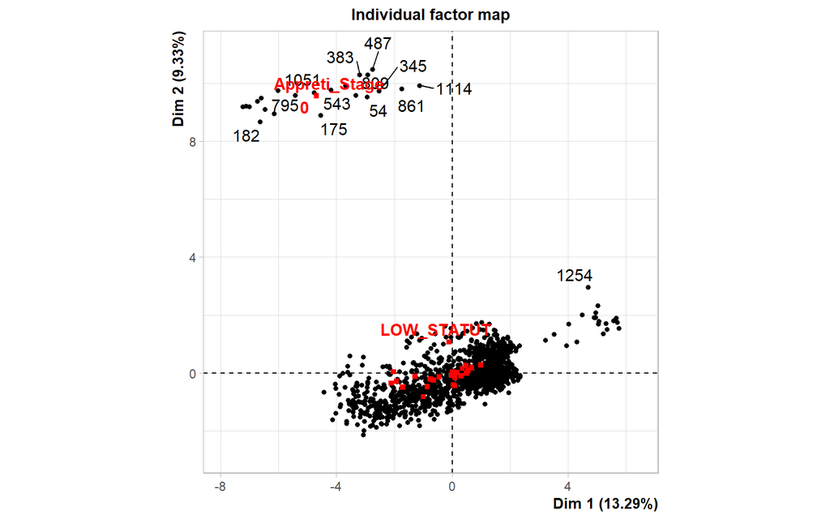

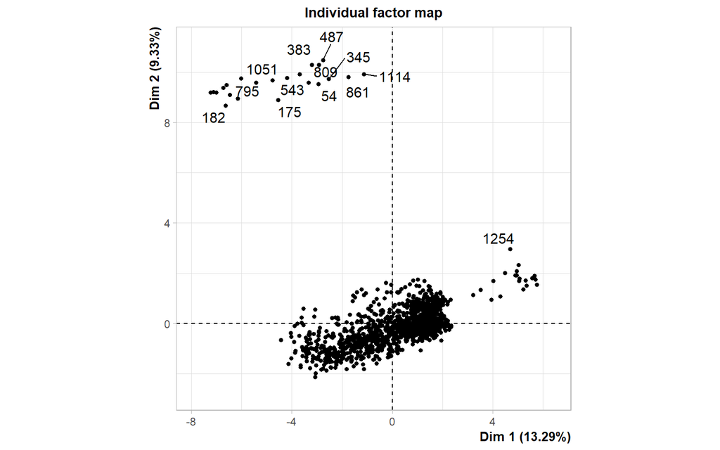

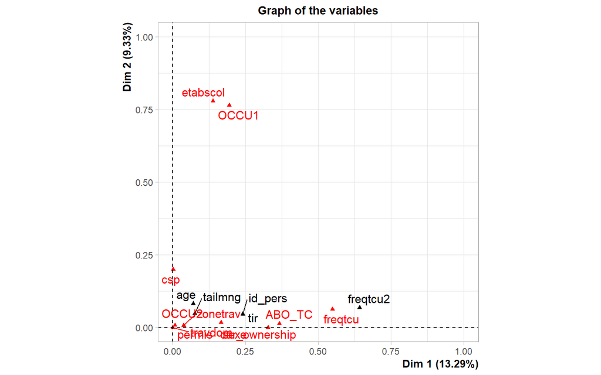

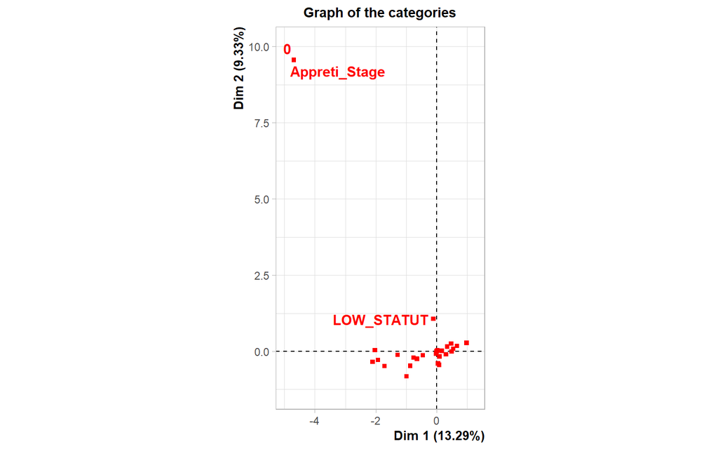

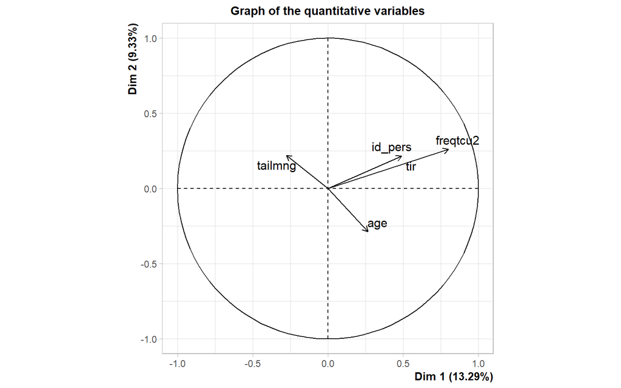

```
##
## Call:
## FAMD(base = DB_pers_socio_1, ncp = 5)
##
##
## Eigenvalues
##                       Dim.1  Dim.2  Dim.3  Dim.4  Dim.5
## Variance              3.057  2.145  1.903  1.504  1.323
## % of var.            13.293  9.326  8.272  6.539  5.753
## Cumulative % of var. 13.293 22.619 30.891 37.430 43.183
##
## Individuals (the 10 first)
##                   Dist    Dim.1    ctr   cos2    Dim.2    ctr   cos2    Dim.3
## 1             |  4.265 |  1.247  0.040  0.085 | -0.054  0.000  0.000 | -2.201
## 2             |  4.024 | -1.519  0.060  0.142 | -0.547  0.011  0.018 | -0.571
## 3             |  4.773 | -2.286  0.135  0.229 | -1.032  0.039  0.047 | -0.364
## 4             |  6.942 | -3.857  0.385  0.309 | -1.086  0.043  0.024 |  0.601
## 5             |  4.385 | -0.872  0.020  0.040 |  0.135  0.001  0.001 | -0.978
## 6             |  5.439 | -2.364  0.145  0.189 | -0.389  0.006  0.005 |  0.193
## 7             |  3.998 | -0.086  0.000  0.000 | -1.150  0.049  0.083 | -1.365
## 8             |  4.410 | -2.717  0.191  0.380 | -1.643  0.100  0.139 |  0.342
## 9             |  5.345 | -1.957  0.099  0.134 | -1.372  0.069  0.066 |  0.187
## 10            |  5.427 | -3.022  0.236  0.310 | -1.091  0.044  0.040 |  0.328
##                  ctr   cos2
## 1              0.201  0.266 |
## 2              0.014  0.020 |
## 3              0.006  0.006 |
## 4              0.015  0.008 |
## 5              0.040  0.050 |
## 6              0.002  0.001 |
## 7              0.077  0.117 |
## 8              0.005  0.006 |
## 9              0.001  0.001 |
## 10             0.004  0.004 |
##
## Continuous variables
##                  Dim.1    ctr   cos2    Dim.2    ctr   cos2    Dim.3    ctr
## tir           |  0.491  7.871  0.241 |  0.215  2.154  0.046 |  0.804 33.943
## age           |  0.266  2.313  0.071 | -0.287  3.845  0.082 |  0.188  1.855
## id_pers       |  0.490  7.864  0.240 |  0.215  2.156  0.046 |  0.804 33.946
```

[output cut: 17 more lines]

```
## BAC+2         |  -0.020   0.001   0.000  -0.187 |  -0.079   0.023   0.001
## BEP           |   0.025   0.001   0.000   0.205 |   0.034   0.003   0.000
## CAP           |   0.346   0.216   0.022   3.169 |   0.155   0.088   0.004
## PAS DIPLOME   |  -0.646   0.088   0.008  -1.864 |  -0.246   0.026   0.001
##                v.test     Dim.3     ctr    cos2  v.test
## Femme          -4.698 |   0.627   5.047   0.233  15.059 |
## Homme           4.698 |  -0.545   4.390   0.233 -15.059 |
## 0              30.884 |  -0.132   0.008   0.000  -0.452 |
## APPRENTISSAGE  -0.192 |   1.441   0.272   0.010   2.565 |
## BAC            -1.527 |   0.359   0.441   0.018   3.479 |
## BAC >= 3       -7.985 |   0.016   0.002   0.000   0.301 |
## BAC+2          -0.876 |  -0.049   0.011   0.000  -0.570 |
## BEP             0.330 |  -0.171   0.112   0.005  -1.766 |
## CAP             1.694 |  -0.244   0.278   0.011  -2.833 |
## PAS DIPLOME    -0.849 |   0.936   0.478   0.017   3.424 |
```